# Your Digest for Tuesday, Mar 12, 2024 11:59 PM

[figure not shown]

- Strawberry cervix
- Frothy, green vaginal discharge.
- Treat with oral metronidazole.

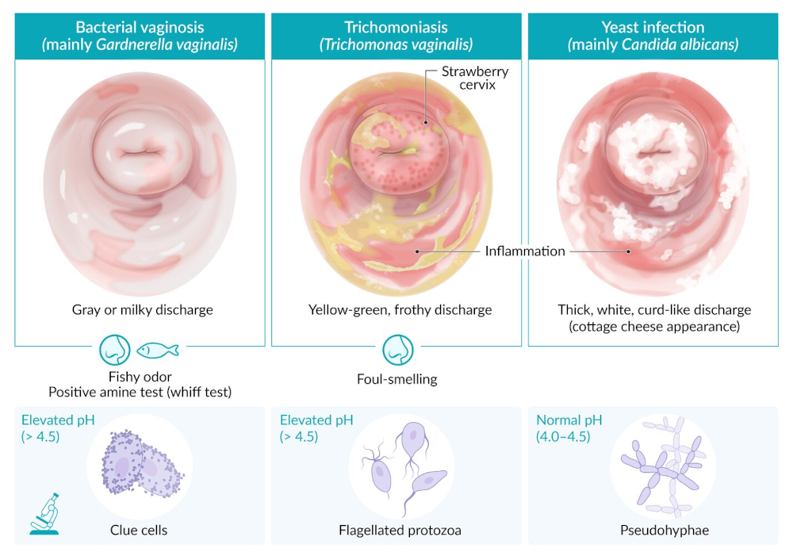

- Cell turnover rate is increased in psoriasis. (turnover period of 4 - 5 days Vs. 40 - 50 days in normal skin.) [Source](https://onlinelibrary.wiley.com/doi/full/10.1111/cpr.13441)
- But proliferation rate is also increased much more -> Overall effect is **hyperkeratosis**.
- Epidermal hyperplasia + other changes;
- **Parakeratosis** - persistence of *nuclei in stratum corneum*.  
  Guttate psoriasis occurs with **strep infection**; usually seen in children and adoslescents .  
  Another classic sign of chronic plaque psoriasis:  
  visualization of pinpoint bleeding after removal of scale overlying a psoriatic plaque.
- **improves during pregnancy** and *worsens post partum* (maybe because progesterone in pregnancy downregulates T cell proliferative response). [Source](https://www.ncbi.nlm.nih.gov/pmc/articles/PMC1889937/)
  - Mnemonic: pregnancy - one 1, post partum - 2ps, means worsens *p*soriasis
  - Mnemonic: LAMBDA - lithium, anti-inflammatory , m-antimalarias, B - beta blockers, D-doxycycline (tetracyclines)

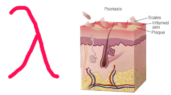

- Psoriasis is *usually* **non pruritic**.
- Erythrodermic psoriasis is **painful**.

## Subtypes of psoriasis

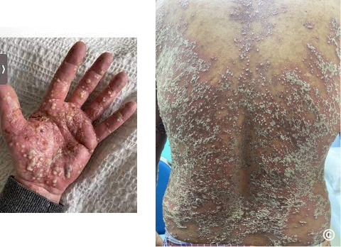

- Can be *localized palmoplantar* pustular psoriasis.
- (most severe form is **Von-Zumbusch** - generalized pustular psoriasis)
  - Fever, **leukocytosis**, **hypocalcemia**.
  - Possibly complicated by **sepsis** and **renal** / **hepatic** involvement.
- *Pustular psoriasis of pregnancy*: usually occurring **during T3 of pregnancy**.
- Erythrodermic psoriasis usually occurs in the *setting of known worsening or unstable psoriasis*.
- Generalized - Involves most the body surface; erythema and scaling.
- High risk of complications due to loss of barrier function:
  - Sepsis
  - Electrolyte abnormality
  - Fluid loss
- *Low calcium*
- Withdrawal or excessive use of strong [topical corticosteroids](https://dermnetnz.org/topics/topical-steroid)
- *Oedema* (swelling), particularly of lower legs

## Overview of treatment of psoriasis

[output not shown]

- **Topical dithranol** is an option; it has anti proliferative effects. (inhibits DNA synthesis)
  - Acitretin is not immunosuppressive
- **Tonsillectomy** (due to association with *strep infection*) has been show to improve psoriasis (esp. *guttate psoriasis*)
- **AKA** *generalized exfoliative dermatitis*.

> [!INFO] ⭐**Humans** are the only host of these.😔

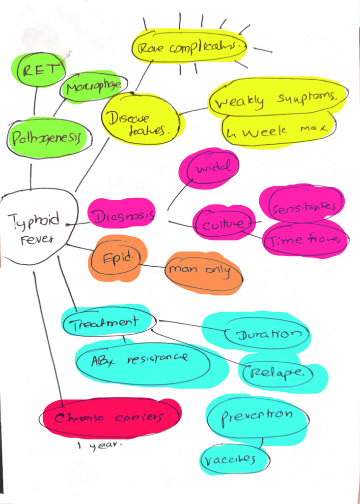

- ⭐**Positive culture** is the **only confirmatory test** of enteric fever.
  - Blood - "early in the disease"; **Blood culture is the mainstay of diagnosis** of enteric fever. Even so, sensitivity is not 100% (40-80%). Time to positive yield is reduced by centrifugation and culture **of the buffy coat** because the bacteria live inside the WBCs.
  - Urine and faecies - "first week"[Source](https://www.epid.gov.lk/storage/post/pdfs/fact_sheet_wh_enteric_fever_updated.pdf)
  - Bone marrow culture is valuable because it remains positive for upto 5 days after commencement of antibiotic therapy.
  - Of little clinical value because it's positive even with previous infection. Also has low specificity.
  - Checks antibodies to O and H antigens of salmonella. (O antigen - cell wall components, H antigen - the flagellar antigen)
  - However, **four fold rise in titre** is **confirmatory**.

#2016GM-OCT/Q10 ⭐

[figure not shown]

- **Drug resistance** is a key issue.
- Resistance is common to chloramphenicol, amoxicillin, cotrimoxazole. - the older antibiotics used of enteric fever.
  - most strains remain sensitive to Gen 3 cephalosporins and azithyromycin.
- Some indian studies show increasing resistance to ciprofoloxacin but a recurrence of sensitivity to chloramphenicol , cotrimoxazole and ampicillin.
  - In sri lanka, 2016 guideline suggests ceftriaxone for 10-14 days.
- **Most patients can be managed at home** with oral antibiotics. - Harrison's.
- **Response**:
  - successful treatment in uncomplicated cases results in clinical improvement in 3-5 days, with *fever clearance* at 4-6 days.
  - *Duration* Antibiotics 10 - 14 days (or atleast 5 days after resolution of fever)
  - *Relapse* can happen 2 to 3 weeks after resolution.
- **Carriers**: To be treated with 4 weeks of ciprofloxacin (Harrison's)
- Single dose IM vaccine with booster in 3 years to be given to food handlers.
  - This is the capsular polysaccharide vaccine.
- The other vaccine (Ty21a) is live attenuated and given as a capsule.
  - Based on O and H antigens.
- High risk groups who should get the vaccine:

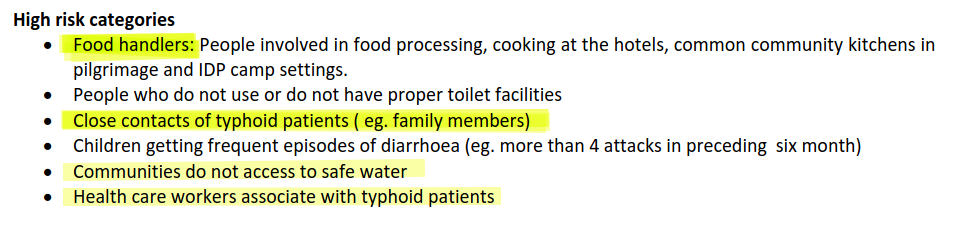

> [!INFO] Stroke mimics to rule out (**5S**)  
> Sugar  
> Seizure  
> Syncope  
> SOL  
> Sepsis

[figure not shown]

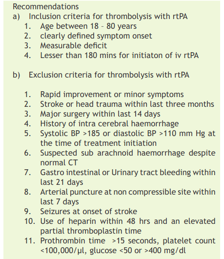